# Week 1 Peer Review

### Put your name here: ARSHJOT SINGH

**IMPORTANT: Filter your data so you are only displaying information for the 115th Congress.**

## Exercise 1

Hints:

- For the y-axis, use the variable “all_pass”.
- For the x-axis, use the variable “dwnom1”.
- Make sure you recode the data for the “female” variable and rename it as “Gender” to generate the correct labels for the legend.
- Set the color aesthetic in the ggplot() function to make the color of the dots change based on Gender.
- Make sure the axis labels are correct.

```
## # A tibble: 6 × 38
##   thomas_num thomas_name icpsr congress  year st_name    cd   dem elected Gender
##        <dbl> <chr>       <dbl>    <dbl> <dbl> <chr>   <dbl> <dbl>   <dbl> <chr>
## 1       9807 Abraham, R… 21522      115  2017 LA          5     0    2014 Male
## 2       9808 Adams, Alma 21545      115  2017 NC         12     1    2014 Female
## 3       9809 Aderholt, … 29701      115  2017 AL          4     0    1996 Male
## 4       9810 Aguilar, P… 21506      115  2017 CA         31     1    2014 Male
## 5       9811 Allen, Rick 21516      115  2017 GA         12     0    2014 Male
## 6       9812 Amash, Jus… 21143      115  2017 MI          3     0    2010 Male
## # ℹ 28 more variables: votepct <dbl>, dwnom1 <dbl>, deleg_size <dbl>,
## #   speaker <dbl>, subchr <dbl>, afam <dbl>, latino <dbl>, votepct_sq <dbl>,
## #   power <dbl>, chair <dbl>, state_leg <dbl>, state_leg_prof <dbl>,
## #   majority <dbl>, maj_leader <dbl>, min_leader <dbl>, meddist <dbl>,
## #   majdist <dbl>, all_bills <dbl>, all_aic <dbl>, all_abc <dbl>,
## #   all_pass <dbl>, all_law <dbl>, les <dbl>, seniority <dbl>, benchmark <dbl>,
## #   expectation <dbl>, TotalInParty <dbl>, RankInParty <dbl>
```

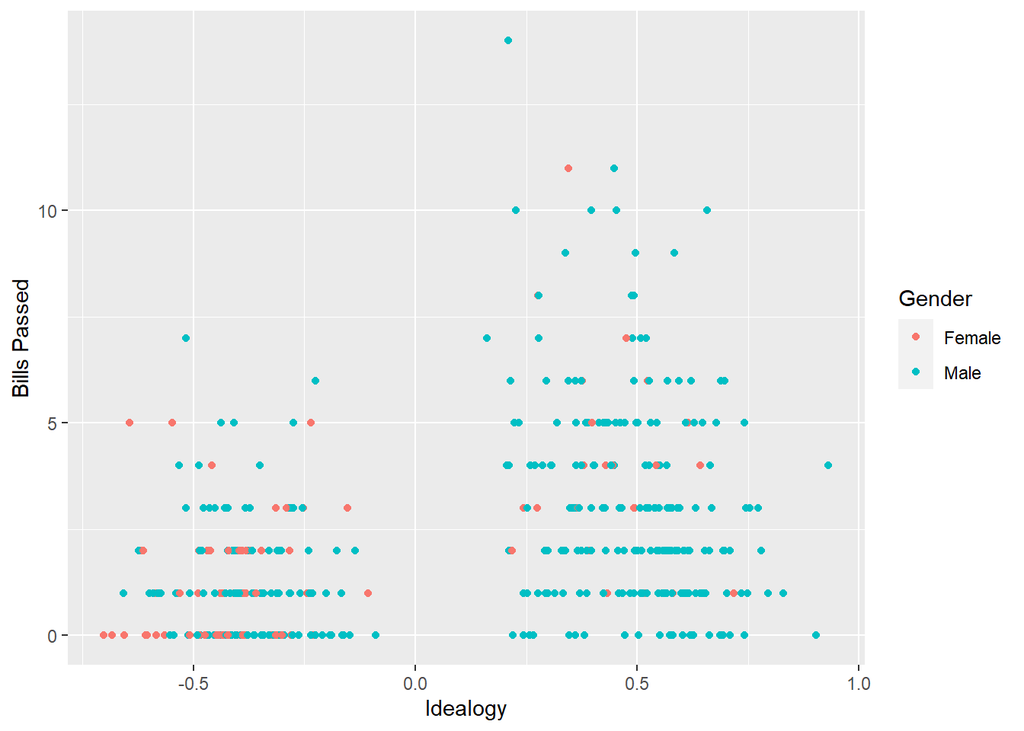

## Exercise 2

Hints:

- For the x-axis, use the variable “votepct”.
- For the y-axis, use “all_pass”.
- Make sure you recode the data for the “female” variable to generate the correct labels for the legend. Rename that column “Gender”. (you may have already done this in the last exercise)
- Make sure you recode the data for “majority” variable to generate the correct labels of the facetted figures.
- Set the color aesthetic in the ggplot() function to make the color of the dots change based on Gender.
- Use scale_color_manual() to set the colors to green for males and orange for females.
- Make sure the axis labels are correct.

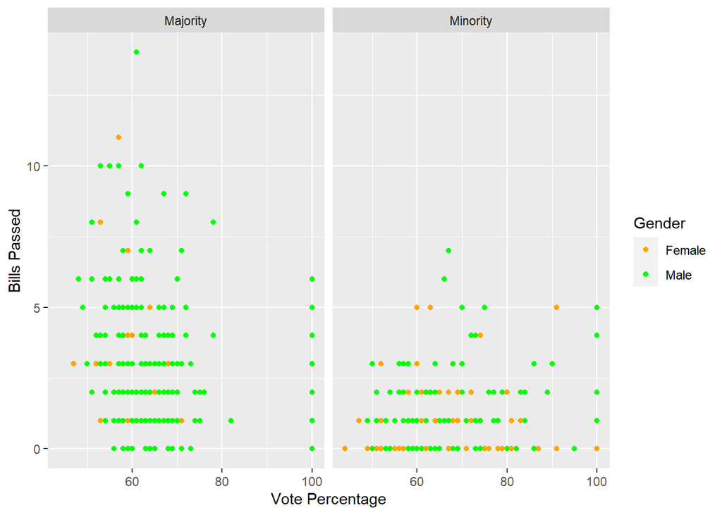

## Exercise 3

Hints:

- For the y-axis, use the variable “les”.
- Make sure you recode the data for the “majority” variable to generate the correct labels. (you may have already done this in the last exercise)
- Make sure the axis labels and figure title are correct.

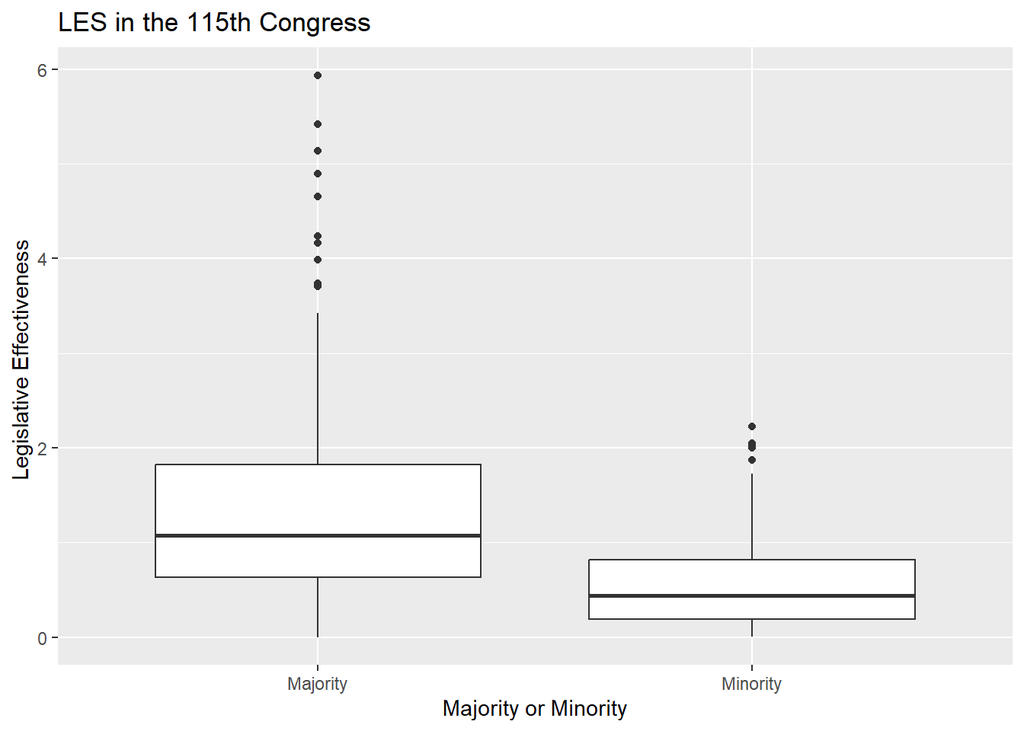